# Predicting NBA Regular Season Records To Find Undervalued or Overvalued Playoff Teams

</br>

##### by Akhil Chamarthy, Pranav Jayaraman, Anirudh Vadrevu, and Henry Vuong

An investigation on how regular season NBA statistics can be used to create an expected wins model that can then be used to determine if a team over performed or underperformed their expected win column.

#### 1. Exploratory Analysis of Data

#### 2. Darwin Supervised Learning

#### 3. Conclusion

# Exploratory Analysis of Data

To analyze this problem, we decided to use regular season NBA data from the past 10 years. We scraped this data from the official NBA website (https://stats.nba.com/teams/), and added several of our own columns as well. The official NBA data had dozens of categories, including Traditional, Advanced, Four Factors, Misc, Scoring, Opponent, and Defense; each of these categories contained different pieces of data. For example, true shooting percentage (a statistic that measures how efficiently a player shot the ball) fell under Advanced, but field goal percentage (the number of shots made over the number of shots taken) fell under Traditional.

Our feature engineered columns were number players who received NBA awards during that season. These awards are given to top players at their position as voted by fans, media, and coaches. The features we created were:

- Number of All Star players
- Number of All-NBA 1st team players
- Number of All-NBA 2nd team players
- Number of All-NBA 3rd team players

Before running Darwin, we decided to explore our full dataset and its features.

```python
import pandas as pd
import matplotlib.pyplot as plt
%matplotlib inline
```

```python
df = pd.read_csv("NBA_Combined_Data.csv")
df.head()
```

|  | TEAM | "+/-" | %FGA 2PT | %FGA 3PT | %PTS 2PT | %PTS 2PT-MR | %PTS 3PT | %PTS FBPS | %PTS FT | %PTS OFFTO | ... | PIE | PITP | PTS | PTS OFF TO | REB | REB% | STL | TOV | TOV% | TS% |
| --- | --- | --- | --- | --- | --- | --- | --- | --- | --- | --- | --- | --- | --- | --- | --- | --- | --- | --- | --- | --- | --- |
| 0 | Atlanta Hawks | -5.5 | 63.7 | 36.3 | 52.2 | 12.3 | 32.5 | 10.0 | 15.3 | 17.2 | ... | 46.8 | 10.4 | 103.4 | 0.6 | 41.9 | 48.9 | 7.8 | 15.5 | 15.7 | 54.7 |
| 1 | Boston Celtics | 3.6 | 64.3 | 35.7 | 51.6 | 13.4 | 33.0 | 9.1 | 15.3 | 14.8 | ... | 51.9 | 9.5 | 104.0 | 0.6 | 44.5 | 50.4 | 7.4 | 14.0 | 14.4 | 55.2 |
| 2 | Brooklyn Nets | -3.7 | 58.9 | 41.1 | 47.9 | 6.8 | 35.7 | 10.0 | 16.3 | 13.3 | ... | 47.4 | 10.7 | 106.6 | 0.6 | 44.4 | 48.9 | 6.2 | 15.2 | 15.1 | 55.1 |
| 3 | Charlotte Hornets | 0.3 | 68.6 | 31.4 | 53.5 | 13.1 | 27.9 | 8.6 | 18.7 | 14.9 | ... | 50.0 | 9.3 | 108.2 | 0.6 | 45.5 | 51.2 | 6.8 | 12.7 | 12.8 | 54.9 |
| 4 | Chicago Bulls | -7.0 | 65.0 | 35.0 | 53.6 | 13.1 | 32.2 | 11.4 | 14.1 | 14.6 | ... | 45.3 | 11.8 | 102.9 | 0.6 | 44.7 | 50.0 | 7.6 | 14.0 | 14.0 | 52.9 |

5 rows × 94 columns

```python
df.columns
```

```
Index(['TEAM', '"+/-"', '%FGA 2PT\n ', '%FGA 3PT\n ', '%PTS 2PT\n ',
       '%PTS 2PT-MR\n ', '%PTS 3PT\n ', '%PTS FBPS\n ', '%PTS FT\n ',
       '%PTS OFFTO', '%PTS PITP', '2FGM %AST', '2FGM %UAST', '2ND PTS',
       '3FGM %AST', '3FGM %UAST', '3P%', '3PA', '3PM', 'All-NBA First Team',
       'All-NBA Second Team', 'All-NBA Third Team', 'AST', 'AST RATIO',
       'AST/TO', 'AST%', 'BLK', 'BLKA', 'DEF RTG', 'DREB', 'DREB%', 'EFG%',
       'FBPS', 'FG%', 'FGA', 'FGM', 'FGM %AST', 'FGM %UAST', 'FT%', 'FTA',
       'FTA RATE', 'FTM', 'ActualLabel', 'Label', 'NETRTG', 'Num of All Stars',
       'OFFRTG', 'OPP 2ND PTS', 'OPP 3P%', 'OPP 3PA', 'OPP 3PM', 'OPP AST',
       'OPP BLK', 'OPP BLKA', 'OPP DREB', 'OPP EFG%', 'OPP FBPS', 'OPP FG%',
       'OPP FGA', 'OPP FGM', 'OPP FT%', 'OPP FTA', 'OPP FTA RATE', 'OPP FTM',
       'OPP OREB', 'OPP OREB%', 'OPP PF', 'OPP PFD', 'OPP PITP', 'OPP PTS',
       'OPP PTS 2ND CHANCE', 'OPP PTS FB', 'OPP PTS OFF TO', 'OPP PTS OFF TOV',
       'OPP PTS PAINT', 'OPP REB', 'OPP STL', 'OPP TOV', 'OPP TOV%', 'OREB',
       'OREB%', 'PACE', 'PF', 'PFD', 'PIE', 'PITP', 'PTS', 'PTS\n OFF TO',
       'REB', 'REB%', 'STL', 'TOV', 'TOV%', 'TS%'],
      dtype='object')
```

First, we decided to plot Win% against Points to see if there was any correlation. We found that there was generally a positive correlation, so the more points a team scores, the higher its winning percentage is likely to be.

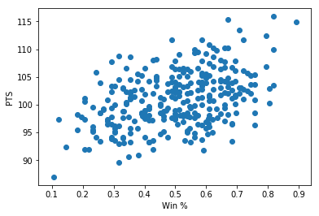

```python
plt.scatter(df['Label'], df['PTS'])
plt.xlabel('Win %')
plt.ylabel('PTS')
plt.show()
```

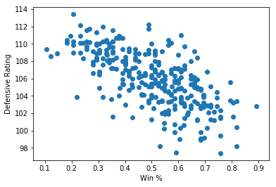

```python
plt.scatter(df['Label'], df['DEF RTG'])
plt.xlabel('Win %')
plt.ylabel('Defensive Rating')
plt.show()
```

We continued to plot Win% against variables to check correlations and explore the data.

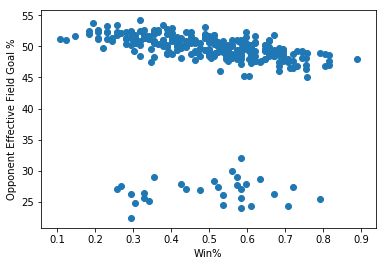

```python
plt.scatter(df['Label'], df['OPP EFG%'])
plt.xlabel('Win%')
plt.ylabel('Opponent Effective Field Goal %')
plt.show()
```

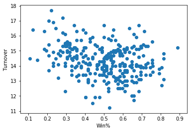

```python
plt.scatter(df['Label'], df['TOV'])
plt.xlabel('Win%')
plt.ylabel('Turnover ')
plt.show()
```

We plotted label against Points, and found that good teams (labels 0 and 1) generally had higher PTS, which made sense considering our earlier plot.

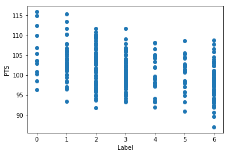

```python
plt.scatter(df['ActualLabel'], df['PTS'])
plt.xlabel('Label')
plt.ylabel('PTS')
plt.show()
```

We wanted to explore if a better shooting team (measured by True Shooting %) meant a team would score more points, and we found this to be true.

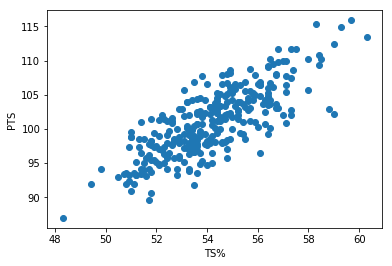

```python
plt.scatter(df['TS%'], df['PTS'])
plt.xlabel('TS%')
plt.ylabel('PTS')
plt.show()
```

We also wanted to see if the Number of All-Stars a team had correlated in any way to the number of points the team scored. We found that teams that had at least 1 All-Star generally did as well with teams with multiple All-Stars, and even many of the teams with 0 All-Stars scored a lot of points.

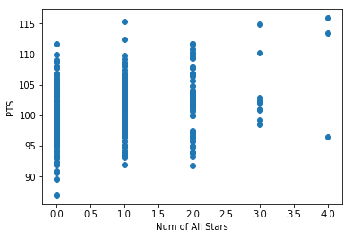

```python
plt.scatter(df['Num of All Stars'], df['PTS'])
plt.xlabel('Num of All Stars')
plt.ylabel('PTS')
plt.show()
```

We then explored Win% by Number of All-Stars, and found that the greater the number of All-Stars a team has, the higher its winning % is.

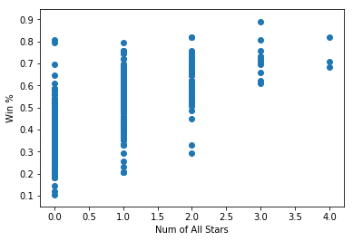

```python
plt.scatter(df['Num of All Stars'], df['Label'])
plt.xlabel('Num of All Stars')
plt.ylabel('Win %')
plt.show()
```

Considering the rise of the 3-pointer in the modern NBA, we wanted to explore the effect of how good a team is at 3-point shooting on the teams' overall points per game. We found that better 3-point shooting teams score more points.

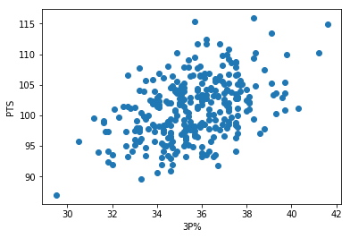

```python
plt.scatter(df['3P%'], df['PTS'])
plt.xlabel('3P%')
plt.ylabel('PTS')
plt.show()
```

We also wanted to explore if a better shooting free-throw team would shoot three-pointers equally well, but we found that is not necessarily the case.

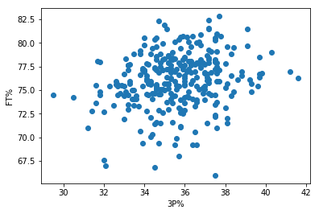

```python
plt.scatter(df['3P%'], df['FT%'])
plt.xlabel('3P%')
plt.ylabel('FT%')
plt.show()
```

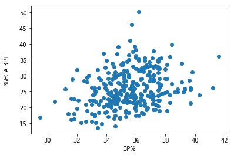

```python
plt.scatter(df['3P%'], df['%FGA 3PT\n '])
plt.xlabel('3P%')
plt.ylabel('%FGA 3PT\n ')
plt.show()
```

We then explored the distribution of several variables.

[output not shown]

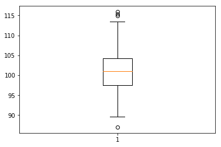

```python
plt.boxplot(df['PTS'])
```

[output not shown]

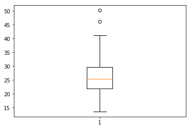

```python
plt.boxplot(df['%FGA 3PT\n '])
```

# Darwin Supervised Learning

## Darwin Model v1.0

We will now build a model using Darwin's Supervised Learning model that will use the wins percentage column as our label.  
Our labels are NBA teams regular season records binned as so:

[output not shown]

*Exclusive then inclusive for win ranges*

Initially, we fed Darwin our entire dataset. We thought that Darwin would normalize and scale our data, and would also perform feature selection and use the most important features to create the best model. However, we ran models using this method approx. ~50 times while fine tuning parameters, but were frustrated when the accuracy of our models failed to improve. We realized that Darwin may not have been performing feature selection and was overfitting our training data, so we decided to use the most important features from this model, which used every feature, and run another model with only these features included.

## Darwin Model v2.0

The section below illustrates the steps to setup the Darwin environment, upload our datsets, clean the datsets, create our model, and test our model.

### Set Darwin SDK

```python
from amb_sdk.sdk import DarwinSdk
ds = DarwinSdk()
ds.set_url('https://amb-demo-api.sparkcognition.com/v1/')
```

```
(True, 'https://amb-demo-api.sparkcognition.com/v1/')
```

### Environment Variables

```python
# Set path to datasets - The default below assumes Jupyter was started from amb-sdk/examples/Enterprise/
# Modify accordingly if you wish to use your own data
PATH_TO_DATASET='sets/'
TRAIN_DATASET='nba_train.csv'
TEST_DATASET='nba_test.csv'
# A timestamp is used to create a unique name in the event you execute the workflow multiple times or with
# different datasets.  File names must be unique in Darwin.
import datetime
ts = '{:%Y%m%d%H%M%S}'.format(datetime.datetime.now())
```

### Import necessary libraries

```python
# Import necessary libraries
%matplotlib inline
import matplotlib.pyplot as plt
import pandas as pd
from IPython.display import Image
from time import sleep
import os
import numpy as np
from sklearn.metrics import classification_report
```

### User Login

```python
status, msg = ds.auth_login_user('henryvuong2408@yahoo.com','j2ZZKMwMer')
if not status:
    print(msg)
```

### Data Upload and Clean

```python
# Preview dataset
df = pd.read_csv(os.path.join(PATH_TO_DATASET, TRAIN_DATASET))
df.head()
```

|  | "+/-" | DEF RTG | FG% | NETRTG | Num of All Stars | OFFRTG | OPP EFG% | OPP FG% | OPP PTS OFF TOV | PIE | Wins |
| --- | --- | --- | --- | --- | --- | --- | --- | --- | --- | --- | --- |
| 0 | 0.9 | 105.2 | 45.1 | -0.7 | 0 | 104.5 | 50.7 | 44.4 | 17.4 | 50.6 | 2 |
| 1 | -2.6 | 108.0 | 45.4 | 2.6 | 1 | 110.6 | 50.3 | 45.0 | 15.2 | 51.4 | 1 |
| 2 | 6.7 | 110.1 | 44.4 | -6.5 | 0 | 103.6 | 51.3 | 45.8 | 19.1 | 46.0 | 4 |
| 3 | -0.2 | 108.4 | 44.2 | -0.1 | 1 | 108.4 | 52.3 | 45.6 | 13.1 | 50.5 | 3 |
| 4 | -0.4 | 106.2 | 44.4 | 0.3 | 1 | 106.5 | 50.7 | 45.6 | 15.5 | 50.4 | 2 |

**Upload dataset to Darwin**

```python
# Upload dataset
status, dataset = ds.upload_dataset(os.path.join(PATH_TO_DATASET, TRAIN_DATASET))
if not status:
    print(dataset)
```

**Clean dataset**

```python
# clean dataset
target = "Wins"
status, job_id = ds.clean_data(TRAIN_DATASET, target = target)

if status:
    ds.wait_for_job(job_id['job_name'])
else:
    print(job_id)
```

```
{'status': 'Requested', 'starttime': '2019-04-21T16:45:01.815804', 'endtime': None, 'percent_complete': 0, 'job_type': 'CleanDataTiny', 'loss': None, 'generations': None, 'dataset_names': ['nba_train.csv'], 'artifact_names': ['92a879bb7e5846aaa71c54615e3bf087'], 'model_name': None, 'job_error': None…
{'status': 'Complete', 'starttime': '2019-04-21T16:45:01.815804', 'endtime': '2019-04-21T16:45:03.617756', 'percent_complete': 100, 'job_type': 'CleanDataTiny', 'loss': None, 'generations': None, 'dataset_names': ['nba_train.csv'], 'artifact_names': ['92a879bb7e5846aaa71c54615e3bf087'], 'model_name'…
```

### Create and Train Model

```python
model = target + "_model0" + ts
ds.delete_model(model)
status, job_id = ds.create_model(dataset_names = TRAIN_DATASET, \
                                 model_name =  model, \
                                 max_train_time = '00:02')
if status:
    ds.wait_for_job(job_id['job_name'])
else:
    print(job_id)
```

```
{'status': 'Requested', 'starttime': '2019-04-21T16:50:30.93327', 'endtime': None, 'percent_complete': 0, 'job_type': 'TrainModel', 'loss': None, 'generations': 0, 'dataset_names': ['nba_train.csv'], 'artifact_names': None, 'model_name': 'Wins_model020190421134148', 'job_error': None}
{'status': 'Running', 'starttime': '2019-04-21T16:50:30.93327', 'endtime': None, 'percent_complete': 4, 'job_type': 'TrainModel', 'loss': 1.2826470136642456, 'generations': 5, 'dataset_names': ['nba_train.csv'], 'artifact_names': None, 'model_name': 'Wins_model020190421134148', 'job_error': ''}
{'status': 'Running', 'starttime': '2019-04-21T16:50:30.93327', 'endtime': None, 'percent_complete': 16, 'job_type': 'TrainModel', 'loss': 1.2826470136642456, 'generations': 5, 'dataset_names': ['nba_train.csv'], 'artifact_names': None, 'model_name': 'Wins_model020190421134148', 'job_error': ''}
{'status': 'Running', 'starttime': '2019-04-21T16:50:30.93327', 'endtime': None, 'percent_complete': 28, 'job_type': 'TrainModel', 'loss': 1.2826470136642456, 'generations': 5, 'dataset_names': ['nba_train.csv'], 'artifact_names': None, 'model_name': 'Wins_model020190421134148', 'job_error': ''}
{'status': 'Running', 'starttime': '2019-04-21T16:50:30.93327', 'endtime': None, 'percent_complete': 40, 'job_type': 'TrainModel', 'loss': 1.2826470136642456, 'generations': 5, 'dataset_names': ['nba_train.csv'], 'artifact_names': None, 'model_name': 'Wins_model020190421134148', 'job_error': ''}
{'status': 'Running', 'starttime': '2019-04-21T16:50:30.93327', 'endtime': None, 'percent_complete': 50, 'job_type': 'TrainModel', 'loss': 1.2826470136642456, 'generations': 7, 'dataset_names': ['nba_train.csv'], 'artifact_names': None, 'model_name': 'Wins_model020190421134148', 'job_error': ''}
{'status': 'Running', 'starttime': '2019-04-21T16:50:30.93327', 'endtime': None, 'percent_complete': 50, 'job_type': 'TrainModel', 'loss': 1.2826470136642456, 'generations': 7, 'dataset_names': ['nba_train.csv'], 'artifact_names': None, 'model_name': 'Wins_model020190421134148', 'job_error': ''}
{'status': 'Running', 'starttime': '2019-04-21T16:50:30.93327', 'endtime': None, 'percent_complete': 50, 'job_type': 'TrainModel', 'loss': 1.2826470136642456, 'generations': 7, 'dataset_names': ['nba_train.csv'], 'artifact_names': None, 'model_name': 'Wins_model020190421134148', 'job_error': ''}
{'status': 'Running', 'starttime': '2019-04-21T16:50:30.93327', 'endtime': None, 'percent_complete': 50, 'job_type': 'TrainModel', 'loss': 1.2826470136642456, 'generations': 7, 'dataset_names': ['nba_train.csv'], 'artifact_names': None, 'model_name': 'Wins_model020190421134148', 'job_error': ''}
{'status': 'Complete', 'starttime': '2019-04-21T16:50:30.93327', 'endtime': '2019-04-21T16:52:37.040772', 'percent_complete': 100, 'job_type': 'TrainModel', 'loss': 1.2826470136642456, 'generations': 7, 'dataset_names': ['nba_train.csv'], 'artifact_names': None, 'model_name': 'Wins_model020190421134…
```

### Extra Training

```python
# Train some more
status, job_id = ds.resume_training_model(dataset_names = TRAIN_DATASET,
                                          model_name = model,
                                          max_train_time = '00:05')

if status:
    ds.wait_for_job(job_id['job_name'])
else:
    print(job_id)
```

```
{'status': 'Requested', 'starttime': '2019-04-21T16:55:23.216245', 'endtime': None, 'percent_complete': 0, 'job_type': 'UpdateModel', 'loss': 1.2826470136642456, 'generations': 15, 'dataset_names': ['nba_train.csv'], 'artifact_names': None, 'model_name': 'Wins_model020190421134148', 'job_error': Non…
{'status': 'Running', 'starttime': '2019-04-21T16:55:23.216245', 'endtime': None, 'percent_complete': 1, 'job_type': 'UpdateModel', 'loss': 1.257951021194458, 'generations': 15, 'dataset_names': ['nba_train.csv'], 'artifact_names': None, 'model_name': 'Wins_model020190421134148', 'job_error': ''}
{'status': 'Running', 'starttime': '2019-04-21T16:55:23.216245', 'endtime': None, 'percent_complete': 1, 'job_type': 'UpdateModel', 'loss': 1.257951021194458, 'generations': 15, 'dataset_names': ['nba_train.csv'], 'artifact_names': None, 'model_name': 'Wins_model020190421134148', 'job_error': ''}
{'status': 'Running', 'starttime': '2019-04-21T16:55:23.216245', 'endtime': None, 'percent_complete': 8, 'job_type': 'UpdateModel', 'loss': 1.257951021194458, 'generations': 18, 'dataset_names': ['nba_train.csv'], 'artifact_names': None, 'model_name': 'Wins_model020190421134148', 'job_error': ''}
{'status': 'Complete', 'starttime': '2019-04-21T16:55:23.216245', 'endtime': '2019-04-21T16:56:15.832999', 'percent_complete': 100, 'job_type': 'UpdateModel', 'loss': 1.257951021194458, 'generations': 18, 'dataset_names': ['nba_train.csv'], 'artifact_names': None, 'model_name': 'Wins_model0201904211…
```

### Analyze Model

```python
# Retrieve feature importance of built model
status, artifact = ds.analyze_model(model)
sleep(1)
if status:
    ds.wait_for_job(artifact['job_name'])
else:
    print(artifact)
status, feature_importance = ds.download_artifact(artifact['artifact_name'])
```

```
{'status': 'Running', 'starttime': '2019-04-21T16:56:33.808242', 'endtime': None, 'percent_complete': 0, 'job_type': 'AnalyzeModel', 'loss': 1.257951021194458, 'generations': 18, 'dataset_names': None, 'artifact_names': ['7f45c71116ef48ee9700d33c11c61e52'], 'model_name': 'Wins_model020190421134148',…
{'status': 'Complete', 'starttime': '2019-04-21T16:56:33.808242', 'endtime': '2019-04-21T16:56:41.568635', 'percent_complete': 100, 'job_type': 'AnalyzeModel', 'loss': 1.257951021194458, 'generations': 18, 'dataset_names': None, 'artifact_names': ['7f45c71116ef48ee9700d33c11c61e52'], 'model_name': '…
```

Show the 10 most important features of the model.

```python
feature_importance[:10]
```

```
NETRTG                  0.324885
PIE                     0.264925
"+/-"                   0.114925
OFFRTG                  0.084745
DEF RTG                 0.056869
FG%                     0.056184
OPP FG%                 0.039728
OPP EFG%                0.029311
OPP PTS OFF TOV         0.021177
Num of All Stars = 2    0.003284
dtype: float64
```

## Predictions

**Perform model prediction on the the training dataset.**

```python
status, artifact = ds.run_model(TRAIN_DATASET, model)
sleep(1)
ds.wait_for_job(artifact['job_name'])
```

```
{'status': 'Running', 'starttime': '2019-04-21T16:56:58.891997', 'endtime': None, 'percent_complete': 0, 'job_type': 'RunModel', 'loss': 1.257951021194458, 'generations': 18, 'dataset_names': ['nba_train.csv'], 'artifact_names': ['4d134395e10c4b5b9349d38812c6868b'], 'model_name': 'Wins_model02019042…
{'status': 'Complete', 'starttime': '2019-04-21T16:56:58.891997', 'endtime': '2019-04-21T16:57:06.390744', 'percent_complete': 100, 'job_type': 'RunModel', 'loss': 1.257951021194458, 'generations': 18, 'dataset_names': ['nba_train.csv'], 'artifact_names': ['4d134395e10c4b5b9349d38812c6868b'], 'model…
```

```
(True, 'Job completed')
```

Download predictions from Darwin's server.

```python
status, prediction = ds.download_artifact(artifact['artifact_name'])
prediction.head()
```

|  | Wins | prob_0 | prob_1 | prob_2 | prob_3 | prob_4 |
| --- | --- | --- | --- | --- | --- | --- |
| 0 | 2 | 0.021263 | 0.102416 | 0.703244 | 0.157136 | 0.015941 |
| 1 | 1 | 0.153084 | 0.607036 | 0.202787 | 0.032566 | 0.004527 |
| 2 | 4 | 0.005748 | 0.010939 | 0.033186 | 0.316257 | 0.633870 |
| 3 | 2 | 0.020678 | 0.141093 | 0.628427 | 0.196693 | 0.013108 |
| 4 | 2 | 0.018012 | 0.127977 | 0.688514 | 0.155019 | 0.010478 |

After running our training dataset to our model, we produced a 82% weigthed accuracy. The precision and recall is shown below.

```
              precision    recall  f1-score   support

           0       0.92      0.77      0.84        44
           1       0.72      0.78      0.75        49
           2       0.78      0.87      0.82        61
           3       0.78      0.72      0.75        39
           4       0.91      0.89      0.90        46

   micro avg       0.81      0.81      0.81       239
   macro avg       0.82      0.81      0.81       239
weighted avg       0.82      0.81      0.81       239
```

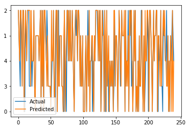

```python
unq = df[target].unique()[::-1]
p = np.zeros((len(prediction),))
a = np.zeros((len(prediction),))
for i,q in enumerate(unq):
    p += i*(prediction[target] == q).values
    a += i*(df[target] == q).values
#Plot predictions vs actual
plt.plot(a)
plt.plot(p)
plt.legend(['Actual','Predicted'])
plt.yticks([i for i in range(len(unq))],[q for q in unq]);
print(classification_report(df[target][:239], prediction[target][:239]))
```

**Perform model prediction on a test dataset that wasn't used in training.**  
**Upload test dataset**

```python
status, dataset = ds.upload_dataset(os.path.join(PATH_TO_DATASET, TEST_DATASET))
if not status:
    print(dataset)
```

**Clean test dataset**

```python
# clean test dataset
status, job_id = ds.clean_data(TEST_DATASET, target = target, model_name = model)

if status:
    ds.wait_for_job(job_id['job_name'])
else:
    print(job_id)
```

```
{'status': 'Requested', 'starttime': '2019-04-21T16:57:29.386779', 'endtime': None, 'percent_complete': 0, 'job_type': 'CleanDataTiny', 'loss': None, 'generations': None, 'dataset_names': ['nba_test.csv'], 'artifact_names': ['1ff6973e370c4392ba0193e04351fd8f'], 'model_name': None, 'job_error': None}
{'status': 'Complete', 'starttime': '2019-04-21T16:57:29.386779', 'endtime': '2019-04-21T16:57:30.738197', 'percent_complete': 100, 'job_type': 'CleanDataTiny', 'loss': None, 'generations': None, 'dataset_names': ['nba_test.csv'], 'artifact_names': ['1ff6973e370c4392ba0193e04351fd8f'], 'model_name':…
```

**Run model on test dataset.**

```python
status, artifact = ds.run_model(TEST_DATASET, model)
sleep(1)
ds.wait_for_job(artifact['job_name'])
```

```
{'status': 'Running', 'starttime': '2019-04-21T16:57:58.372189', 'endtime': None, 'percent_complete': 0, 'job_type': 'RunModel', 'loss': 1.257951021194458, 'generations': 18, 'dataset_names': ['nba_test.csv'], 'artifact_names': ['f4a065cb072c47eda796a03dcd707dc4'], 'model_name': 'Wins_model020190421…
{'status': 'Complete', 'starttime': '2019-04-21T16:57:58.372189', 'endtime': '2019-04-21T16:57:59.909216', 'percent_complete': 100, 'job_type': 'RunModel', 'loss': 1.257951021194458, 'generations': 18, 'dataset_names': ['nba_test.csv'], 'artifact_names': ['f4a065cb072c47eda796a03dcd707dc4'], 'model_…
```

```
(True, 'Job completed')
```

```
              precision    recall  f1-score   support

           0       0.89      0.73      0.80        11
           1       0.79      0.69      0.73        16
           2       0.50      1.00      0.67         9
           3       0.71      0.50      0.59        10
           4       1.00      0.86      0.92        14

   micro avg       0.75      0.75      0.75        60
   macro avg       0.78      0.75      0.74        60
weighted avg       0.80      0.75      0.76        60
```

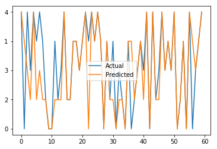

```python
# Create plots comparing predictions with actual target
status, prediction = ds.download_artifact(artifact['artifact_name'])
df = pd.read_csv(os.path.join(PATH_TO_DATASET, TEST_DATASET))
unq = prediction[target].unique()[::-1]
p = np.zeros((len(prediction),))
a = np.zeros((len(prediction),))
for i,q in enumerate(unq):
    p += i*(prediction[target] == q).values
    a += i*(df[target] == q).values
#Plot predictions vs actual
plt.plot(a)
plt.plot(p)
plt.legend(['Actual','Predicted'])
plt.yticks([i for i in range(len(unq))],[q for q in unq]);
print(classification_report(df[target][:60], prediction[target][:60]))
```

## Using our model to predict the 2019 Playoffs:

Now that we hav our model trained, let's upload the 2019 NBA season and see which teams were overvalued and undervalued

```python
# upload nba 2019 dataset
nba_2019_DATASET = 'nba_2019.csv'
status, dataset = ds.upload_dataset(os.path.join(PATH_TO_DATASET, nba_2019_DATASET))
# clearn dataset
status, job_id = ds.clean_data(nba_2019_DATASET, target = target, model_name = 'Wins_model020190421134148')
# run model on dataset
status, artifact = ds.run_model(nba_2019_DATASET, 'Wins_model020190421134148')
sleep(1)
ds.wait_for_job(artifact['job_name'])
```

```
{'status': 'Running', 'starttime': '2019-04-23T16:16:53.583201', 'endtime': None, 'percent_complete': 0, 'job_type': 'RunModel', 'loss': 1.257951021194458, 'generations': 18, 'dataset_names': ['nba_2019.csv'], 'artifact_names': ['a4d15bd2896f4d5d87cb0a12c343c703'], 'model_name': 'Wins_model020190421…
{'status': 'Complete', 'starttime': '2019-04-23T16:16:53.583201', 'endtime': '2019-04-23T16:17:02.682703', 'percent_complete': 100, 'job_type': 'RunModel', 'loss': 1.257951021194458, 'generations': 18, 'dataset_names': ['nba_2019.csv'], 'artifact_names': ['a4d15bd2896f4d5d87cb0a12c343c703'], 'model_…
```

```
(True, 'Job completed')
```

```
              precision    recall  f1-score   support

           0       0.75      0.60      0.67         5
           1       0.75      0.75      0.75         8
           2       0.64      1.00      0.78         7
           3       1.00      0.33      0.50         6
           4       0.80      1.00      0.89         4

   micro avg       0.73      0.73      0.73        30
   macro avg       0.79      0.74      0.72        30
weighted avg       0.78      0.73      0.71        30
```

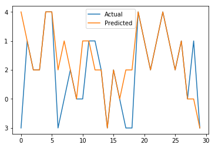

```python
# Create plots comparing predictions with actual target
status, prediction = ds.download_artifact(artifact['artifact_name'])
df = pd.read_csv(os.path.join(PATH_TO_DATASET, nba_2019_DATASET))
unq = prediction[target].unique()[::-1]
p = np.zeros((len(prediction),))
a = np.zeros((len(prediction),))
for i,q in enumerate(unq):
    p += i*(prediction[target] == q).values
    a += i*(df[target] == q).values
#Plot predictions vs actual
plt.plot(a)
plt.plot(p)
plt.legend(['Actual','Predicted'])
plt.yticks([i for i in range(len(unq))],[q for q in unq]);
print(classification_report(df[target][:30], prediction[target][:30]))
```

There were a total of eight teams total that over/under performed expectation, four of those teams being playoff contenders. The Denver Nuggets, LA Clippers, and Houston Rockets won more games than expected and the Utah Jazz won less games than expected.